# Result Analysis

In this notebook, we perform a result analysis of our model in two aspects:

1. whether the model is able to differentiate similar papers published by the same author, while at the same time discovering their shared topics
2. whether the model is able to give precise results compared to manual labeling

To start, we select 5 papers published by Professor Shang:

- CrossWeigh
  - Semantic Scholar: https://www.semanticscholar.org/paper/CrossWeigh%3A-Training-Named-Entity-Tagger-from-Wang-Shang/997855e1f17d34dd3922d953a587742d198844e6
  - PDF: https://www.aclweb.org/anthology/D19-1519.pdf
- AutoPhrase
  - Semantic Scholar: https://www.semanticscholar.org/paper/Automated-Phrase-Mining-from-Massive-Text-Corpora-Shang-Liu/96808500be49f3d502055bab1edd30dcbec4b99b
  - PDF: http://hanj.cs.illinois.edu/pdf/tkde18_jshang2.pdf
- LM-LSTM-CRF
  - Semantic Scholar: https://www.semanticscholar.org/paper/Empower-Sequence-Labeling-with-Task-Aware-Neural-Liu-Shang/7647a06965d868a4f6451bef0818994100a142e8
  - PDF: https://arxiv.org/pdf/1709.04109.pdf
- AutoNER
  - Semantic Scholar: https://www.semanticscholar.org/paper/Learning-Named-Entity-Tagger-using-Domain-Specific-Shang-Liu/5201efab94c9376ef894f6f33cab06a5c5e00073
  - PDF: https://www.aclweb.org/anthology/D18-1230.pdf
- SetExpan
  - Semantic Scholar: https://www.semanticscholar.org/paper/SetExpan%3A-Corpus-Based-Set-Expansion-via-Context-Shen-Wu/741d50647afac926dce001160d8253c7a5c14ca3
  - PDF: https://arxiv.org/pdf/1910.08192.pdf

```
['CrossWeigh', 'AutoNER', 'LM-LSTM-CRF', 'AutoPhrase', 'SetExpan']
```

### 1. Ability to compare and contrast similar papers published by the same author

First we get the AutoPhrase results for all 5 papers. We select high quality phrases (quality score > 0.5) only.

|  | CrossWeigh phrase | CrossWeigh score | AutoNER phrase | AutoNER score | LM-LSTM-CRF phrase | LM-LSTM-CRF score | AutoPhrase phrase | AutoPhrase score | SetExpan phrase | SetExpan score |
| --- | --- | --- | --- | --- | --- | --- | --- | --- | --- | --- |
| 0 | maccabi tel aviv | 0.953615 | jiawei han | 0.883683 | neural networks | 0.9455 | information extraction | 0.900436 | bipartite graph | 0.861667 |
| 1 | hapoel jerusalem | 0.947004 | association for computational linguistics | 0.838017 | conll03 ner | 0.8955 | knowledge base | 0.898069 | data model | 0.810833 |
| 2 | natural language processing | 0.876014 | test f1 | 0.831583 | highway layers | 0.8715 | domain specific | 0.863229 | entity intrusion | 0.803333 |
| 3 | tel aviv org | 0.853902 | natural language | 0.826750 | language model | 0.8135 | text corpora | 0.845831 | semantic drift | 0.740667 |
| 4 | lstm cnns crf | 0.836071 | xiang ren | 0.797167 | pos tagging | 0.8105 | high quality phrases | 0.830262 | california | 0.731913 |
| 5 | natural language | 0.792397 | domain specific | 0.788800 | bi lstm | 0.8095 | quality single word phrases | 0.822869 | pubmed cvd | 0.731000 |
| 6 | association for computational linguistics | 0.786124 | modified iobes | 0.785000 | highway units | 0.7855 | phrase mining | 0.798362 | texas | 0.730487 |
| 7 | computational linguistics | 0.773940 | ablation experiments | 0.761417 | sequence labeling | 0.7615 | wikipedia article datasets | 0.790736 | grained types | 0.719167 |
| 8 | cross validation | 0.759089 | pre rec f1 | 0.760083 | lstm crf | 0.7555 | dw ½ | 0.789586 | io n pte word2vec egoset seisa | 0.714667 |
| 9 | entity disjoint filtering | 0.748422 | lstm crf | 0.707050 | conditional random | 0.7545 | phrase quality | 0.787390 | skip gram | 0.714333 |
| 10 | potentially mistake | 0.744366 | named entity | 0.703500 | transfer learning | 0.7525 | single word phrases | 0.779024 | ranked lists | 0.707000 |
| 11 | named entity recognition | 0.742255 | data | 0.680852 | ner task | 0.7485 | auc | 0.776646 | act | 0.706530 |
| 12 | entity disjoint | 0.726647 | dictionary | 0.679280 | state size | 0.7365 | word sequence | 0.770474 | candidate entities | 0.699167 |
| 13 | chicago | 0.720033 | tagging scheme | 0.673500 | word embedding | 0.7355 | cn | 0.767391 | free text | 0.697500 |
| 14 | pos tagging | 0.717565 | knowledge | 0.672533 | task specific | 0.7345 | raw frequency | 0.765840 | expanded set | 0.692833 |

As we can see from the dataframe above, there are some phrases, such as "maccabi tel aviv," "jiawei han," and "california," that ended up at the top of the ranked list while they are actually not domain-specific.

To filter out these nonsignificant phrases, our model applies weight to the AutoPhrase result using the pre-processed arXiv dataset. For pre-processing, we have split the arXiv dataset into domains and run AutoPhrase on each of them to get domain specific phrases. For the 5 papers we are using, we select the domain to be "computer science" and the weighted results with high quality phrases (quality score > 0.5) are as follows:

|  | CrossWeigh phrase | CrossWeigh score | AutoNER phrase | AutoNER score | LM-LSTM-CRF phrase | LM-LSTM-CRF score | AutoPhrase phrase | AutoPhrase score | SetExpan phrase | SetExpan score |
| --- | --- | --- | --- | --- | --- | --- | --- | --- | --- | --- |
| 0 | natural language processing | 0.838990 | natural language | 0.790789 | neural networks | 0.854883 | knowledge base | 0.873407 | bipartite graph | 0.829287 |
| 1 | natural language | 0.757931 | domain specific | 0.741383 | pos tagging | 0.786385 | information extraction | 0.856859 | skip gram | 0.664785 |
| 2 | computational linguistics | 0.740970 | named entity | 0.673549 | bi lstm | 0.732485 | domain specific | 0.811338 | ranked lists | 0.644381 |
| 3 | cross validation | 0.718658 | distant supervision | 0.627576 | sequence labeling | 0.732107 | text corpora | 0.770488 | semantic drift | 0.628639 |
| 4 | named entity recognition | 0.705910 | lstm crf | 0.597881 | word embedding | 0.714797 | keyphrase extraction | 0.719894 | text corpora | 0.609257 |
| 5 | pos tagging | 0.696215 | ablation experiments | 0.580176 | transfer learning | 0.703784 | pos tagger | 0.712723 | texas | 0.608994 |
| 6 | lstm crf | 0.606123 | distantly supervised | 0.561613 | language model | 0.698183 | natural language | 0.690965 | coarse grained | 0.607136 |
| 7 | chicago | 0.593747 | ncbi | 0.536222 | word embeddings | 0.667826 | massive text corpora | 0.650525 | california | 0.601513 |
| 8 | japan | 0.571026 | ner | 0.516699 | lstm crf | 0.638850 | cn | 0.630996 | skip grams | 0.600160 |
| 9 | f1 | 0.537041 | ram | 0.516429 | conditional random | 0.630958 | auc | 0.630004 | ranked list | 0.590317 |
| 10 | china | 0.530006 | f1 | 0.507561 | f1 score | 0.625515 | pos tag | 0.625162 | act | 0.574041 |
| 11 | nz | 0.524289 | liu | 0.505426 | named entity recognition | 0.608186 | ieee | 0.618373 | free text | 0.563177 |
| 12 | loc | 0.509845 | NaN | NaN | task specific | 0.601384 | wikipedia | 0.609086 | apr | 0.563165 |
| 13 | mi | 0.500274 | NaN | NaN | highway layers | 0.594081 | illinois | 0.604065 | usa | 0.561447 |
| 14 | NaN | NaN | NaN | NaN | language models | 0.593771 | domain experts | 0.594662 | pubmed | 0.557891 |

Thus our model is able to differentiate similar papers published by the same author, while at the same time discovering their shared topics.

The density plots of quality scores before and after applying weight are as follows:

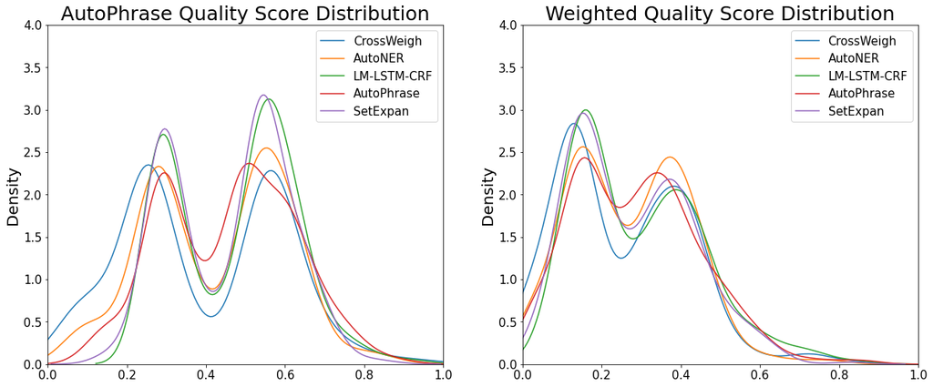

The quality score distribution shifts to the left after applying the weight. This is expected because nonsignificant phrases are weighted down.

### 2. Ability to give precise results comparing to manual labeling

To do this, we annotate the weighted results by manual checking and labeling whether the phrases can actually represent the paper. We compare the accuracy for phrases with a quality score > 0.5, > 0.6, and > 0.7.

|  | Article | Accuracy (quality score > 0.5) | Accuracy (quality score > 0.6) | Accuracy (quality score > 0.7) |
| --- | --- | --- | --- | --- |
| 0 | CrossWeigh | 0.642857 | 1.000000 | 1.0 |
| 1 | AutoNER | 0.833333 | 1.000000 | 1.0 |
| 2 | LM-LSTM-CRF | 0.888889 | 0.923077 | 1.0 |
| 3 | AutoPhrase | 0.780000 | 0.857143 | 1.0 |
| 4 | SetExpan | 0.629630 | 0.888889 | 1.0 |

As we can see from the dataframe above, accuracy is higher for phrases with a higher quality score.

Thus our model is able to give precise results compared to manual labeling.

The precision-recall curves are plotted as follows:

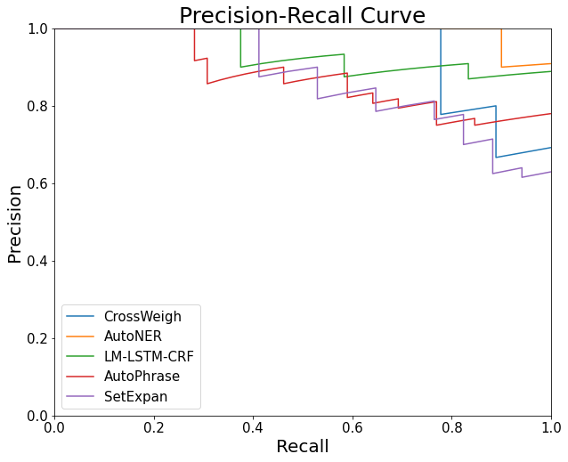